# Introduction to Python for Chemical Engineers

**Edgar Martín Hernández**

**Department of Chemical Engineering**

**University of Salamanca**

[figure not shown]

# Python

- Python is an interpreted high level language
- Very versatile:
  - General programming
  - Modelling
  - Optimization
  - Data science
  - GIS (Geographic Information Systems)
  - Web development
  - and much more

# Python structure

- Python core
- IDEs and editors
- Libraries → additional functions

[figure not shown]

# Installation

Anaconda is a free and open-source distribution including the core of Python, the most common libraries, and some of the most popular IDEs

[figure not shown]

https://www.anaconda.com/products/individual

Recommendable to use Python 3.x

# Hands on!

```python
2+2+6
```

```
10
```

```python
a = 3
a
```

```
3
```

```python
b = 'Python is the best language ever'
b
```

```
'Python is the best language ever'
```

# It works, but it is not very exciting...

# Data structures

- Lists
- Dicionaries
- Tuples

Lists:

- Sequence of ordered elements
- Elements of different types can be mixed
- Allows indexation (first value is index 0!)
- Allows operations

```python
list_test = [1,2.0,4,'San','Alberto']
list_test
```

```
[1, 2.0, 4, 'San', 'Alberto']
```

```python
list_test[-3]
```

```
4
```

```python
list_test.append(8)
list_test
```

```
[1, 2.0, 4, 'San', 'Alberto', 8]
```

```python
list_test2 = ['Mas','cosas']
list_test+list_test2
```

```
[1, 2.0, 4, 'San', 'Alberto', 8, 'Mas', 'cosas']
```

Dictionaries:

- Pairs of key + value elements → "key":vaue
- It is better if the key is a string (even if it is a number)
- No ordered
- Allows some operations

```python
dict1 = {'Amal':3,
        'Feli':1,
        'Hamid':13}
```

```python
dict1
```

```
{'Amal': 3, 'Feli': 1, 'Hamid': 13}
```

```python
dict_test = dict()
```

```python
dict_test['MW_Oxygen'] = 16
dict_test['MW_Hydrogen'] = 1
dict_test['MW_Carbon'] = 12
dict_test
```

```
{'MW_Oxygen': 16, 'MW_Hydrogen': 1, 'MW_Carbon': 12}
```

```python
dict_test['MW_Oxygen']
```

```
16
```

```python
MW_Water = dict_test['MW_Oxygen']+2*dict_test['MW_Hydrogen']
MW_Water
```

```
18
```

Tuples

- Similar to lists but immutable
- Elements of different types can be mixed
- Allow indexing

```python
tuple_test=(1,('soy un dos',2),3,8,'a')
tuple_test
```

```
(1, ('soy un dos', 2), 3, 8, 'a')
```

```python
tuple_test[1]
```

```
('soy un dos', 2)
```

```python
tuple_test.append(3) #This will return an error since tuples are immutable once they are defined
```

```
---------------------------------------------------------------------------
AttributeError                            Traceback (most recent call last)
Cell In [16], line 1
----> 1 tuple_test.append(3)

AttributeError: 'tuple' object has no attribute 'append'
```

# Import libraries

```python
import numpy
import numpy as np
```

```python
# Pi number
np.pi
```

```
3.141592653589793
```

```python
# e number
np.e
```

```
2.718281828459045
```

# Additional functions

```python
np.exp([1,2])
```

```
array([2.71828183, 7.3890561 ])
```

```python
np.log10(100)
```

```
2.0
```

# Trigonometric functions

```python
np.sin(np.pi/2)
```

```
1.0
```

```python
np.tan(np.pi)
```

```
-1.2246467991473532e-16
```

```python
# radians to degree
np.rad2deg(2*np.pi)
```

```
360.0
```

# Numpy data structures

```python
np.array([[4,4.5,6,9.9],[4,4.5,6,9.9]])
```

```
array([[4. , 4.5, 6. , 9.9],
       [4. , 4.5, 6. , 9.9]])
```

```python
x=[3,8.1,21]
np.array(x)
```

```
array([ 3. ,  8.1, 21. ])
```

```python
np.zeros([2,4])
```

```
array([[0., 0., 0., 0.],
       [0., 0., 0., 0.]])
```

```python
np.arange(2,4.2,0.2)
```

```
array([2. , 2.2, 2.4, 2.6, 2.8, 3. , 3.2, 3.4, 3.6, 3.8, 4. ])
```

```python
np.linspace(0,1,9)
```

```
array([0.   , 0.125, 0.25 , 0.375, 0.5  , 0.625, 0.75 , 0.875, 1.   ])
```

```python
a=np.array([[1,2,3,4],
            np.linspace(1,2,4)])
a
```

```
array([[1.        , 2.        , 3.        , 4.        ],
       [1.        , 1.33333333, 1.66666667, 2.        ]])
```

```python
a.shape
```

```
(2, 4)
```

```python
a.size
```

```
8
```

```python
len([2,4,5,6])
```

```
4
```

# Defining our own functions

```python
def a_power_b (a,b):
    solution = a**b
    solution2 = 9

    solution_total = [solution, solution2]
    return solution_total
```

```python
a_power_b(2,3)
```

```
[8, 9]
```

```python
x=a_power_b(2,3)
print(x)
```

```
[8, 9]
```

# Conditional statements and loops

```python
a=3
```

```python
a > 3
```

```
False
```

```python
if a!=4:
    y = 8*a
    print ('a is not equal than 4')
    print (y)
```

```
a is not equal than 4
24
```

```python
b=100
if b<1:
    print ('b is less than 1')
elif b>10:
    print ('b is greater than 10')
else:
    print('b is between 1 and 10')
```

```
b is greater than 10
```

```python
c=-20
if c%2==0:
    print('c is an even number')
    if c<0:
        print('c is an even and negative number')
```

```
c is an even number
c is an even and negative number
```

```python
Fibonacci=[1, 1, 2, 3, 5, 8, 13, 21, 34, 55, 89, 144, 233, 377]
for number in Fibonacci:
    print(number)
```

```
1
1
2
3
5
8
13
21
34
55
89
144
233
377
```

```python
count=0
while count<7:
    count=count+1
    print(count)
```

```
1
2
3
4
5
6
7
```

```python
count=5
while True:
    count = count-1
    print (count)
    if count==0:
        break
```

```
4
3
2
1
0
```

```python
count=3
while True:
    count = count-1

    if count==0:
        continue
    print (count)

    if count==-2:
        break
```

```
2
1
-1
-2
```

```python
count=0
while count<3:
    count=count+1
    print(count)

else:
    print('end')
```

```
1
2
3
end
```

# Scientific computing

### Non-linear algebraic equation

It is possible to solve non-linear equations in Python using a function provided by SciPy. This is the root function, which is contained in the module optimize.

The basic syntax is as follows:

### root(fun, x0, args = (), method = 'hybr')

### Problem: terminal velocity

As an example, we are goign to solve the terminal velocity equation, $u_{t}$, provided by Kunii and Levenspiel in their book “Fluidization Engineering”, Eq. 6.1, using the arbitrary set of parameters described below.

$$u_{t}^{*} = u_{t} \Bigg(\frac{\rho^{2}_{g}}{\mu_{g}\big(\rho_{s} - \rho_{g}\big)g}\Bigg)^{1/3}$$

```python
import numpy as np
from scipy import optimize

g=9.81
fi_s=0.6 #sphericity
rho_s=2330 #particle density (kg/m3)
rho_g=0.1355 #gas density (kg/m3)
mi_g=2.6394E-5 #gas viscosity (kg/m·s)
u_t_star=0.5879
```

```python
#Solving non-linear algebraic equations
def  f_u_t(x_u_t, rho_g, mi_g, rho_s, u_t_star, g):
    return x_u_t*((rho_g**2)/(mi_g*(rho_s-rho_g)*g))**(1/3)-u_t_star
```

```python
u_t=optimize.root(f_u_t, 1, args=(rho_g, mi_g, rho_s, u_t_star,g))
u_t
# type (u_t)
```

```
    fjac: array([[-1.]])
     fun: array([0.])
 message: 'The solution converged.'
    nfev: 4
     qtf: array([-1.33503164e-09])
       r: array([-0.31221797])
  status: 1
 success: True
       x: array([1.88297935])
```

```python
u_t=np.float_(u_t.x)
print ('u_t (m/s) =',u_t)
```

```
u_t (m/s) = 1.882979353110989
```

### Integrating with Python

In Python it is possible to integrate using the integrate module of SciPy.

The module contains several integration algorithms, some of them are classical numerical integration algorithms as the trapezoidal rule, which built-in function is ***trapz***, the composite trapezoidal rule through* **cumtrapz***, the Simpson’s rule defined in the function* **simps***, or the Gauss’s quadrature method, which is implemented in* **fixed_quad***. The integration computing is carried out using a n fixed order, or quadrature if the integration computing uses a fixed tolerance to perform the integration. However, integrate also contains the function* **quad***, which is used for a general purpose integration, and it has two variants,* **dblquad*** and ***tplquad***, for double and triple integrations respectively.

```python
import numpy as np
from scipy import integrate

def  int_func(x, a, b):
    return  a/(b+x**2)
```

```python
a=2
b=1

result = integrate.quad(int_func, -2, np.inf, args=(a,b))
result
```

```
(5.355890089177968, 4.084858336647012e-10)
```

### Differential equations

To solve ordinary differential equations (ODEs), Python has several functions including are ***ode*** and ***odeint***. We will focus on the* **odeint*** function, which is a general purpose function to solve an ordinary differential equation or ODEs systems.

### Problem: Chemical kinetics

Reactions:

$A \rightarrow C $

$ k_1=0.002992$

$k_2=0.01168$

```python
import numpy as np
from scipy import integrate
import matplotlib.pyplot as plt

#Kinetics coeficients
k_1=0.002992
k_2=0.01168

#Kinetic equations definition
def kinetics (C,t):
    #An empty list is created to save the dCdt results
    dCdt=np.zeros(4)

    #C[0]: A concentration
    #C[1]: B concentration
    dCdt[0] = -k_1*C[0] #dCdt[0]: Time variation of A concentration
    dCdt[1] = -k_2*C[1]+k_1*C[0] #dCdt[1]: Time variation of B concentration
    dCdt[2] = k_1*C[0] #dCdt[2]: Time variation of C concentration
    dCdt[3] = k_2*C[1] #dCdt[3]: Time variation of D concentration
    return dCdt

#Initial conditions
C_ini=[1, 0, 0, 0]
#Time interval to evaluate the reactions
t=np.linspace(0,3600,500)
#ODEs resolution
res_C=integrate.odeint(kinetics,C_ini,t)
```

[output not shown]

```python
res_C
```

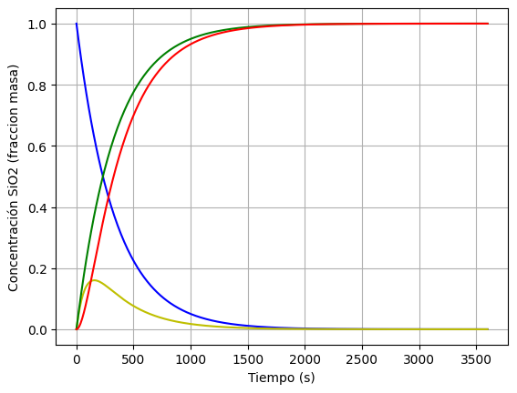

```python
fig,axes=plt.subplots()
axes.plot(t,res_C[:,0],'b')
axes.plot(t,res_C[:,1],'y')
axes.plot(t,res_C[:,2],'g')
axes.plot(t,res_C[:,3],'r')
axes.set_xlabel('Tiempo (s)')
axes.set_ylabel('Concentración SiO2 (fraccion masa)')
axes.grid('on')
plt.show()
```